# Assignment 2: Hand Gesture Recognition [50 Pt]

### Part (iii) - [2pt DISCUSSION]

Choose the best model out of all the ones that you have trained. Justify your choice.

```python
'''
Model 6 is my best model because it's validation error is the lowest (i.e. 15.67% == 84.33% Val Accuracy).
Also model 6 isn't overfitting because train error kept falling with val error also kept falling at bottom of ~16%

'''
```

### Part (iv) - [2pt RESULTS]

Report the test accuracy of your best model. You should only do this step once and prior to this step you should have only used the training and validation data.

Additionally, provide a confusion matrix. Using the confusion matrix values, you must calculate and report the precision, recall, and F1-score for each letter class and report them in a table. Identify the two gestures that your model confuses most often and hypothesize why this might be the case based on their visual similarity.

```python
# ===================== part 1: Test Accuracy ==================

# read my best model weights
ckpt = "/content/model_cnn_bs32_lr0.001_wd5e-05_dp0.3_epoch20"


# classes count
num_classes = len(classes)

# apply trained weights
net = cnn(num_classes=num_classes, p=0.3)
net.load_state_dict(torch.load(ckpt, map_location="cpu"))
net.eval()


# evaluate accuracy
criterion = nn.CrossEntropyLoss()
test_err, _ = evaluate(net, test_loader, criterion, device="cpu")


print(f"Test Accuracy: {(1 - test_err) * 100:.2f}%")
```

[output not shown]

```python
# ========================= part 2: Plot Confusion Matrix =====================

y_pred = []
y_test = []

with torch.no_grad():
  for x, y_onehot in test_loader:
    logit = net(x)    # model 6

    y_pred.append(logit.argmax(1).numpy())
    y_test.append(y_onehot.argmax(1).numpy())

y_pred = np.concatenate(y_pred)
y_test = np.concatenate(y_test)

cm = confusion_matrix(y_test, y_pred,labels=np.arange(num_classes))
print("Confusion Matrix (counts):\n", cm)
```

```
Confusion Matrix (counts):
 [[33  0  0  0  3  0  0  0  0]
 [ 0 34  0  0  0  2  0  0  0]
 [ 0  0 36  0  0  0  0  0  0]
 [ 0  0  0 34  1  0  1  0  1]
 [ 1  0  0  0 35  0  0  0  0]
 [ 0  0  1  0  1 34  0  0  0]
 [ 0  0  0  0  0  0 35  1  0]
 [ 0  0  0  0  0  0  0 36  0]
 [ 0  0  0  0  1  3  0  0 29]]
```

```python
# ===================== part 3: Statistics ==================

TP =np.diag(cm)
FP = cm.sum(axis=0) - TP
TN = cm.sum(axis=1) - TP

precision = TP / (TP + FP)
recall = TN / (TP + TN)

f1 = 2 * (precision * recall) / (precision + recall)

report_df = pd.DataFrame({
    'Class': classes,
    'Precision': precision,
    'Recall': recall,
    'F1-Score': f1
})

print("\nPer-class metrics:")
display(report_df)
```

```
Per-class metrics:
```

|  | Class | Precision | Recall | F1-Score |
| --- | --- | --- | --- | --- |
| 0 | A | 0.970588 | 0.083333 | 0.153488 |
| 1 | B | 1.000000 | 0.055556 | 0.105263 |
| 2 | C | 0.972973 | 0.000000 | 0.000000 |
| 3 | D | 1.000000 | 0.081081 | 0.150000 |
| 4 | E | 0.853659 | 0.027778 | 0.053805 |
| 5 | F | 0.871795 | 0.055556 | 0.104455 |
| 6 | G | 0.972222 | 0.027778 | 0.054012 |
| 7 | H | 0.972973 | 0.000000 | 0.000000 |
| 8 | I | 0.966667 | 0.121212 | 0.215413 |

```python
# ===================== part 4: Confused Pairs ==================

cm_off = cm.copy()
np.fill_diagonal(cm_off, 0)


pairs = [((i, j), cm_off[i, j]) for i in range(num_classes) for j in range(num_classes) if i != j and cm_off[i, j] > 0]
pairs_sorted = sorted(pairs, key=lambda x: x[1], reverse=True)
top2 = pairs_sorted[:2] if len(pairs_sorted) >= 2 else pairs_sorted


print("\nMost confused pairs (true → predicted):")
for (i, j), cnt in top2:
    print(f"- {classes[i]} → {classes[j]} : {cnt} samples")
```

```
Most confused pairs (true → predicted):
- A → E : 3 samples
- I → F : 3 samples
```

```python
'''
The first most confused pair is gesture A & E, because the difference is only the position of thumb and both gestures are fist-like.

The second most confused pair is gesture I & F, because both gestures follow the shape that right-side fingers circled and left-side fingers were raised.

'''
```

## Part 4. Transfer Learning [8pt]

For many image classification tasks, it is generally not a good idea to train a very large deep neural network model from scratch due to the enormous compute requirements and lack of sufficient amounts of training data.

One of the better options is to try using an existing model that performs a similar task to the one you need to solve. This method of utilizing a pre-trained network for other similar tasks is broadly termed **Transfer Learning**. In this assignment, we will use Transfer Learning to extract features from the hand gesture images. Then, train a smaller network to use these features as input and classify the hand gestures.

As you have learned from the CNN lecture, convolution layers extract various features from the images which get utilized by the fully connected layers for correct classification. AlexNet architecture played a pivotal role in establishing Deep Neural Nets as a go-to tool for image classification problems and we will use an ImageNet pre-trained AlexNet model to extract features in this assignment.

### Part (i) - [2pt EXPLORATORY]

Here is the code to load the AlexNet network, with pretrained weights. When you first run the code, PyTorch will download the pretrained weights from the internet.

```python
import torchvision.models
alexnet = torchvision.models.alexnet(pretrained=True)
```

```
Downloading: "https://download.pytorch.org/models/alexnet-owt-7be5be79.pth" to /root/.cache/torch/hub/checkpoints/alexnet-owt-7be5be79.pth
```

The alexnet model is split up into two components: *alexnet.features* and *alexnet.classifier*. The first neural network component, *alexnet.features*, is used to compute convolutional features, which are taken as input in *alexnet.classifier*.

The neural network alexnet.features expects an image tensor of shape Nx3x224x224 as input and it will output a tensor of shape Nx256x6x6 . (N = batch size).

Compute the AlexNet features for each of your training, validation, and test data. Here is an example code snippet showing how you can compute the AlexNet features for some images (your actual code might be different):

```python
features = alexnet.features
IM_MEAN = torch.tensor([0.485, 0.456, 0.406]).view(1,3,1,1)
IM_STD  = torch.tensor([0.229, 0.224, 0.225]).view(1,3,1,1)

def get_fea(loader):
  xs, ys = [], []

  with torch.no_grad():
    for x, y1h in loader:                       # x: [N, 3, 224, 224] in [0, 1]
      x = (x - IM_MEAN) / IM_STD                # image norm
      f = features(x).view(x.size(0), -1)       # f: [N, 256, 6, 6] -> [N, 256*6*6]

      xs.append(f)
      ys.append(y1h.argmax(1))

  return torch.cat(xs), torch.cat(ys)


# feature computation
x_train_features, y_train = get_fea(train_loader)
x_val_features, y_val = get_fea(val_loader)
x_test_features, y_test = get_fea(test_loader)
```

**Save the computed features**. You will be using these features as input to your neural network in Part (ii), and you do not want to re-compute the features every time. Instead, run *alexnet.features* once for each image, and save the result.

```python
# saved computed features
torch.save({"X": x_train_features, "y": y_train, "classes": classes}, "train_feats.pt")
torch.save({"X": x_val_features, "y": y_val, "classes": classes}, "val_feats.pt")
torch.save({"X": x_test_features, "y": y_test, "classes": classes}, "test_feats.pt")
```

### Part (ii) - [2pt MODEL]

Build a new classifier to attach to the AlexNet feature extractor. Your model must use the following sequence of layers:

AlexNet feature → Flatten → Linear → ReLU → Dropout → Linear

Use a dropout probability of 20%; this value can be tuned in the next part. Justify your choice of the Linear layer sizes.

Here is an example of how your model may be called:

```python
# features = ... load precomputed alexnet.features(img) ...
# output = model(features)
# prob = F.softmax(output)
```

```python
# Fully-connected layer

class AlexNetClassifier(nn.Module):
  def __init__(self, p=0.2):
    super(AlexNetClassifier, self).__init__()
    self.fc1 = nn.Linear(256*6*6, 32)
    self.fc2 = nn.Linear(32, 9)
    self.dp = nn.Dropout(p)

  def forward(self, x):
    x = self.dp(F.relu(self.fc1(x)))    # already flatten feature in saved feature in part (i)
    logits = self.fc2(x)                # use Cross Entropy in training, so no softmax here, as CE will include

    return logits
```

```python
'''
I select 2 linear layers to prevent overfitting(compared to >2 layers) and converges more stably(compared to 1 layer).
'''
```

### Part (iii) - [1pt MODEL]

Train your new network, including any hyperparameter tuning. Plot and submit the training curve of your best model only.

Note: Depending on how you are caching (saving) your AlexNet features, PyTorch might still be tracking updates to the **AlexNet weights**, which we are not tuning. One workaround is to convert your AlexNet feature tensor into a numpy array, and then back into a PyTorch tensor.

```python
# tensor = torch.from_numpy(tensor.detach().numpy())
```

```python
from torch.utils.data import TensorDataset

# read saved features
tr = torch.load("train_feats.pt", map_location="cpu")
val = torch.load("val_feats.pt", map_location="cpu")
te = torch.load("test_feats.pt", map_location="cpu")

X_train, y_train, classes = tr["X"], tr["y"], tr["classes"]
X_val, y_val, _ = val["X"], val["y"], val["classes"]
X_test, y_test, _ = te["X"], te["y"], te["classes"]

# block tracking
x_tr = torch.from_numpy(X_train.detach().numpy())
x_val = torch.from_numpy(X_val.detach().numpy())
x_test = torch.from_numpy(X_test.detach().numpy())

g = torch.Generator().manual_seed(seed)

xf_train_loader = DataLoader(TensorDataset(x_tr, y_train), batch_size=BATCH_SIZE, generator=g, shuffle=True)
xf_val_loader = DataLoader(TensorDataset(x_val, y_val), batch_size=BATCH_SIZE, generator=g, shuffle=False)
xf_test_loader = DataLoader(TensorDataset(x_test, y_test), batch_size=BATCH_SIZE, shuffle=False)
```

```python
def get_accuracy(net, loader):
  net.eval()

  correct, total = 0, 0

  with torch.no_grad():
    for xf, label in loader:
      pred = net(xf).argmax(1)

      correct += (label==pred).sum().item()
      total += label.size(0)


  return correct / total
```

```python
# TO BE COMPLETED
def train_alex(net, loader, lr=1e-3, wd=0, dp=0.2,
               batch_size=BATCH_SIZE, num_epochs=20):

  # net = AlexNetClassifier(p=dp)
  criterion = nn.CrossEntropyLoss(reduction='mean')
  optimizer = optim.SGD(net.parameters(), lr=0.01, momentum=0.9)

  iters, losses, train_acc, validation_acc = [], [], [], []
  step = 1

  # training
  for epoch in range(num_epochs):
    net.train()
    for xf, label in loader:

      optimizer.zero_grad()
      logits = net(xf)
      loss = criterion(logits, label)
      loss.backward()
      optimizer.step()

      step+=1

      iters.append(step)
      losses.append(loss.item())

    tr_acc = get_accuracy(net, xf_train_loader)
    val_acc = get_accuracy(net, xf_val_loader)
    train_acc.append(tr_acc)
    validation_acc.append(val_acc)
    print(f"Epoch {epoch+1:02d} | train_acc={tr_acc:.4f} | val_acc={val_acc:.4f} | last_loss={losses[-1]:.4f}")


  # plotting
  plt.title("Training Curve")
  plt.plot(iters, losses, label="Train")
  plt.xlabel("Iterations")
  plt.ylabel("Loss")
  plt.show()

  epochs = list(range(1, len(train_acc)+1))
  plt.title("Training Accuracy")
  plt.plot(epochs, train_acc, label="Train")
  plt.plot(epochs, validation_acc, label="Validation")
  plt.xlabel("Epochs")
  plt.ylabel("Accuracy")
  plt.legend(loc='best')
  plt.show()


  return iters, losses, train_acc, validation_acc, net
```

```
Epoch 01 | train_acc=0.8636 | val_acc=0.8234 | last_loss=0.5741
Epoch 02 | train_acc=0.8923 | val_acc=0.8582 | last_loss=0.4698
Epoch 03 | train_acc=0.9438 | val_acc=0.8607 | last_loss=0.3748
Epoch 04 | train_acc=0.9602 | val_acc=0.8781 | last_loss=0.2773
Epoch 05 | train_acc=0.9801 | val_acc=0.8682 | last_loss=0.3469
Epoch 06 | train_acc=0.9807 | val_acc=0.8657 | last_loss=0.3029
Epoch 07 | train_acc=0.9877 | val_acc=0.8781 | last_loss=0.1414
Epoch 08 | train_acc=0.9947 | val_acc=0.8682 | last_loss=0.0841
Epoch 09 | train_acc=0.9924 | val_acc=0.8706 | last_loss=0.0295
Epoch 10 | train_acc=0.9924 | val_acc=0.8582 | last_loss=0.0528
Epoch 11 | train_acc=0.9965 | val_acc=0.8582 | last_loss=0.2036
Epoch 12 | train_acc=0.9959 | val_acc=0.8657 | last_loss=0.1255
Epoch 13 | train_acc=0.9959 | val_acc=0.8756 | last_loss=0.1106
Epoch 14 | train_acc=0.9977 | val_acc=0.8632 | last_loss=0.0971
Epoch 15 | train_acc=0.9971 | val_acc=0.8955 | last_loss=0.0976
Epoch 16 | train_acc=0.9982 | val_acc=0.8682 | last_loss=0.0660
Epoch 17 | train_acc=0.9994 | val_acc=0.8905 | last_loss=0.1256
Epoch 18 | train_acc=0.9982 | val_acc=0.8806 | last_loss=0.2098
Epoch 19 | train_acc=0.9971 | val_acc=0.8881 | last_loss=0.0740
Epoch 20 | train_acc=0.9988 | val_acc=0.8831 | last_loss=0.0711
```

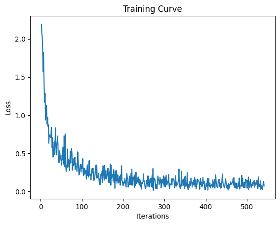

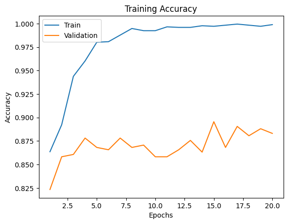

```python
# default model
iters, losses, train_acc, validation_acc, default_model_alex = train_alex(AlexNetClassifier(),  xf_train_loader)
```

```
Epoch 01 | train_acc=0.8653 | val_acc=0.8756 | last_loss=0.6514
Epoch 02 | train_acc=0.9333 | val_acc=0.8458 | last_loss=0.3502
Epoch 03 | train_acc=0.9502 | val_acc=0.8781 | last_loss=0.1561
Epoch 04 | train_acc=0.9631 | val_acc=0.8582 | last_loss=0.3948
Epoch 05 | train_acc=0.9824 | val_acc=0.8557 | last_loss=0.2073
Epoch 06 | train_acc=0.9549 | val_acc=0.8806 | last_loss=0.0669
Epoch 07 | train_acc=0.9977 | val_acc=0.8881 | last_loss=0.1069
Epoch 08 | train_acc=0.9877 | val_acc=0.8980 | last_loss=0.0534
Epoch 09 | train_acc=0.9977 | val_acc=0.8731 | last_loss=0.0888
Epoch 10 | train_acc=0.9982 | val_acc=0.8657 | last_loss=0.0605
Epoch 11 | train_acc=0.9959 | val_acc=0.8831 | last_loss=0.1422
Epoch 12 | train_acc=0.9988 | val_acc=0.8756 | last_loss=0.0358
Epoch 13 | train_acc=1.0000 | val_acc=0.8756 | last_loss=0.0221
Epoch 14 | train_acc=1.0000 | val_acc=0.8756 | last_loss=0.0075
Epoch 15 | train_acc=1.0000 | val_acc=0.8905 | last_loss=0.0882
Epoch 16 | train_acc=0.9982 | val_acc=0.8557 | last_loss=0.0529
Epoch 17 | train_acc=1.0000 | val_acc=0.8781 | last_loss=0.0217
Epoch 18 | train_acc=0.9994 | val_acc=0.8657 | last_loss=0.0055
Epoch 19 | train_acc=1.0000 | val_acc=0.8657 | last_loss=0.0186
Epoch 20 | train_acc=0.9982 | val_acc=0.8731 | last_loss=0.0026
```

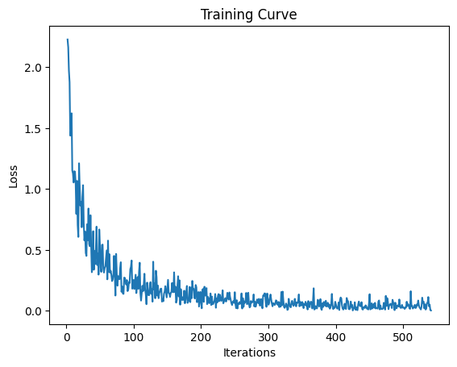

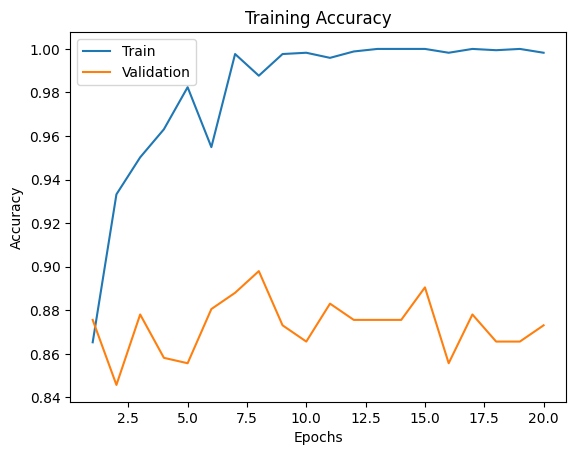

```python
# model 1
iters, losses, train_acc, validation_acc, model_1_alex = train_alex(AlexNetClassifier(),  xf_train_loader,lr=2e-3, wd=1e-4, dp=0.3,
               batch_size=64, num_epochs=20)
```

```
Epoch 01 | train_acc=0.8443 | val_acc=0.8209 | last_loss=0.6103
Epoch 02 | train_acc=0.9093 | val_acc=0.8333 | last_loss=0.5735
Epoch 03 | train_acc=0.9549 | val_acc=0.8632 | last_loss=0.3121
Epoch 04 | train_acc=0.9655 | val_acc=0.8458 | last_loss=0.1380
Epoch 05 | train_acc=0.9795 | val_acc=0.8731 | last_loss=0.1591
Epoch 06 | train_acc=0.9859 | val_acc=0.8582 | last_loss=0.1421
Epoch 07 | train_acc=0.9819 | val_acc=0.8706 | last_loss=0.2110
Epoch 08 | train_acc=0.9924 | val_acc=0.8532 | last_loss=0.1027
Epoch 09 | train_acc=0.9947 | val_acc=0.8657 | last_loss=0.2264
Epoch 10 | train_acc=0.9965 | val_acc=0.9005 | last_loss=0.0719
Epoch 11 | train_acc=0.9982 | val_acc=0.8657 | last_loss=0.0792
Epoch 12 | train_acc=0.9953 | val_acc=0.8905 | last_loss=0.0697
Epoch 13 | train_acc=0.9924 | val_acc=0.8856 | last_loss=0.1722
Epoch 14 | train_acc=0.9971 | val_acc=0.8682 | last_loss=0.0153
Epoch 15 | train_acc=0.9959 | val_acc=0.8731 | last_loss=0.0610
Epoch 16 | train_acc=0.9965 | val_acc=0.8383 | last_loss=0.0037
Epoch 17 | train_acc=1.0000 | val_acc=0.8806 | last_loss=0.0299
Epoch 18 | train_acc=0.9994 | val_acc=0.8731 | last_loss=0.0321
Epoch 19 | train_acc=0.9971 | val_acc=0.8433 | last_loss=0.0215
Epoch 20 | train_acc=0.9994 | val_acc=0.8731 | last_loss=0.0233
```

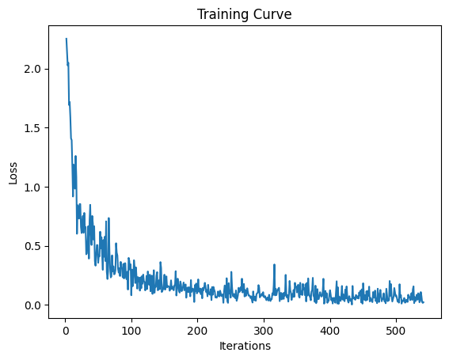

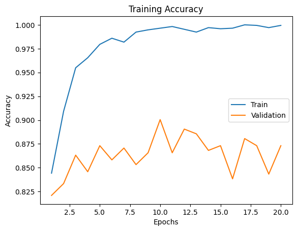

```python
# model 2
iters, losses, train_acc, validation_acc, model_2_alex = train_alex(AlexNetClassifier(),  xf_train_loader,lr=1e-3, wd=1e-4, dp=0.3,
               batch_size=32, num_epochs=20)
```

```
Epoch 01 | train_acc=0.7933 | val_acc=0.7687 | last_loss=0.7388
Epoch 02 | train_acc=0.8864 | val_acc=0.8358 | last_loss=0.5115
Epoch 03 | train_acc=0.8852 | val_acc=0.8308 | last_loss=0.6821
Epoch 04 | train_acc=0.9344 | val_acc=0.8607 | last_loss=0.4301
Epoch 05 | train_acc=0.9063 | val_acc=0.8259 | last_loss=0.3817
Epoch 06 | train_acc=0.9660 | val_acc=0.8682 | last_loss=0.1637
Epoch 07 | train_acc=0.9737 | val_acc=0.8806 | last_loss=0.1279
Epoch 08 | train_acc=0.9848 | val_acc=0.8856 | last_loss=0.2614
Epoch 09 | train_acc=0.9871 | val_acc=0.9005 | last_loss=0.1248
Epoch 10 | train_acc=0.9895 | val_acc=0.8756 | last_loss=0.2957
Epoch 11 | train_acc=0.9900 | val_acc=0.8682 | last_loss=0.2133
Epoch 12 | train_acc=0.9936 | val_acc=0.8756 | last_loss=0.3201
Epoch 13 | train_acc=0.9941 | val_acc=0.8756 | last_loss=0.1745
Epoch 14 | train_acc=0.9918 | val_acc=0.8582 | last_loss=0.2190
Epoch 15 | train_acc=0.9941 | val_acc=0.8980 | last_loss=0.1217
Epoch 16 | train_acc=0.9971 | val_acc=0.8881 | last_loss=0.2510
Epoch 17 | train_acc=0.9965 | val_acc=0.8930 | last_loss=0.1505
Epoch 18 | train_acc=0.9982 | val_acc=0.8955 | last_loss=0.1755
Epoch 19 | train_acc=0.9977 | val_acc=0.8781 | last_loss=0.1118
Epoch 20 | train_acc=0.9988 | val_acc=0.8756 | last_loss=0.0760
```

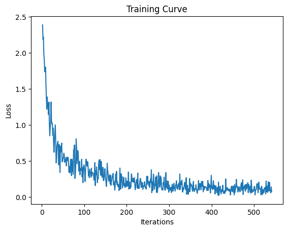

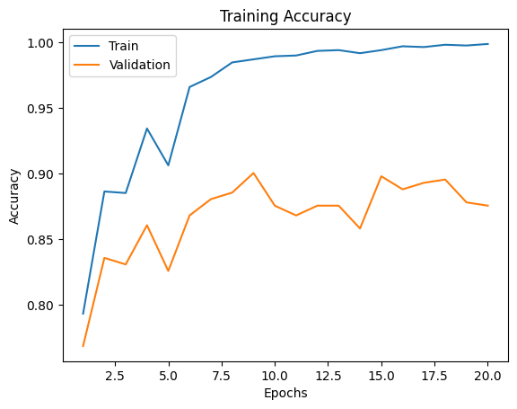

```python
# model 3
iters, losses, train_acc, validation_acc, model_3_alex = train_alex(AlexNetClassifier(),  xf_train_loader,
                                                      lr=3e-3, wd=1e-4, dp=0.25, batch_size=32, num_epochs=20)
```

```
Epoch 01 | train_acc=0.8612 | val_acc=0.8134 | last_loss=0.5864
Epoch 02 | train_acc=0.9133 | val_acc=0.8433 | last_loss=0.8230
Epoch 03 | train_acc=0.9268 | val_acc=0.8433 | last_loss=0.4466
Epoch 04 | train_acc=0.9672 | val_acc=0.8781 | last_loss=0.2324
Epoch 05 | train_acc=0.9666 | val_acc=0.8980 | last_loss=0.3299
Epoch 06 | train_acc=0.9824 | val_acc=0.8706 | last_loss=0.3121
Epoch 07 | train_acc=0.9813 | val_acc=0.8980 | last_loss=0.1214
Epoch 08 | train_acc=0.9900 | val_acc=0.8632 | last_loss=0.2201
Epoch 09 | train_acc=0.9936 | val_acc=0.8856 | last_loss=0.1070
Epoch 10 | train_acc=0.9930 | val_acc=0.8831 | last_loss=0.0507
Epoch 11 | train_acc=0.9941 | val_acc=0.8930 | last_loss=0.1071
Epoch 12 | train_acc=0.9941 | val_acc=0.8806 | last_loss=0.0421
Epoch 13 | train_acc=0.9953 | val_acc=0.8881 | last_loss=0.0374
Epoch 14 | train_acc=0.9959 | val_acc=0.8781 | last_loss=0.0346
Epoch 15 | train_acc=0.9982 | val_acc=0.8731 | last_loss=0.1123
Epoch 16 | train_acc=0.9965 | val_acc=0.8756 | last_loss=0.1314
Epoch 17 | train_acc=0.9977 | val_acc=0.8881 | last_loss=0.0507
Epoch 18 | train_acc=0.9941 | val_acc=0.9055 | last_loss=0.0894
Epoch 19 | train_acc=0.9982 | val_acc=0.8806 | last_loss=0.1999
Epoch 20 | train_acc=0.9965 | val_acc=0.8781 | last_loss=0.1209
```

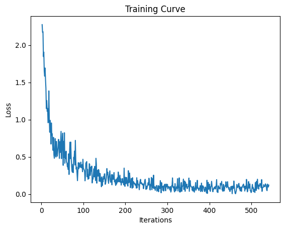

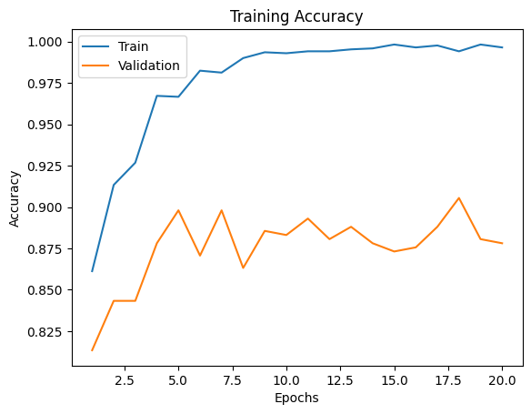

```python
# model 4
iters, losses, train_acc, validation_acc, model_4_alex= train_alex(AlexNetClassifier(),  xf_train_loader,
                                                      lr=1e-3, wd=1e-3, dp=0.3, batch_size=64, num_epochs=20)
```